# Run LGG and HGG survival by splicing cluster assignment and splicing burden

Ryan Corbett

2024

**Purpose:**

Runs survival analysis models using splicing cluster assignment and 1) single exon splicing burden index (SBI) or 2) KEGG Spliceosome GSVA scores as a predictor

## Usage

Uses a wrapper function (`survival_analysis`) from utils folder.

## Setup

#### Packages and functions

Load packages, set directory paths and call setup script

```r
library(tidyverse)
library(survival)
library(ggpubr)
library(ggplot2)
library(patchwork)

root_dir <- rprojroot::find_root(rprojroot::has_dir(".git"))

data_dir <- file.path(root_dir, "data")
analysis_dir <- file.path(root_dir, "analyses", "survival")
input_dir <- file.path(analysis_dir, "results")
results_dir <- file.path(analysis_dir, "results")
plot_dir <- file.path(analysis_dir, "plots")

# If the input and results directories do not exist, create it
if (!dir.exists(results_dir)) {
  dir.create(results_dir, recursive = TRUE)
}

source(file.path(analysis_dir, "util", "survival_models.R"))
```

Set metadata and cluster assignment file paths

```r
metadata_file <- file.path(input_dir, "splicing_indices_with_survival.tsv")

cluster_file <- file.path(root_dir, "analyses",
                          "sample-psi-clustering", "results",
                          "sample-cluster-metadata-top-5000-events-stranded.tsv")

kegg_scores_stranded_file <- file.path(root_dir, "analyses",
                          "sample-psi-clustering", "results",
                          "gsva_output_stranded.tsv")
```

Wrangle data Add cluster assignment and spliceosome gsva scores to `metadata` and define column `lgg_group` (LGG or non_LGG)

```r
metadata <- read_tsv(metadata_file)
clusters <- read_tsv(cluster_file) %>%
  dplyr::rename(Kids_First_Biospecimen_ID = sample_id)
gsva_scores <- read_tsv(kegg_scores_stranded_file) %>%
  dplyr::filter(geneset == "KEGG_SPLICEOSOME") %>%
  dplyr::rename(spliceosome_gsva_score = score)
# how many clusters?
n_clust <- length(unique(clusters$cluster))

metadata <- metadata %>%
  right_join(clusters %>% dplyr::select(Kids_First_Biospecimen_ID,
                                       cluster)) %>%
  left_join(gsva_scores %>% dplyr::select(sample_id,
                                          spliceosome_gsva_score),
            by = c("Kids_First_Biospecimen_ID" = "sample_id")) %>%
  dplyr::mutate(cluster = glue::glue("Cluster {cluster}")) %>%
  dplyr::mutate(cluster = fct_relevel(cluster,
                                               paste0("Cluster ", 1:n_clust))) %>%
  dplyr::mutate(lgg_group = case_when(
    plot_group == "Low-grade glioma" ~ "LGG",
    TRUE ~ "non-LGG"
  )) %>%
  dplyr::mutate(SBI = SI_Total * 10) %>%
  dplyr::mutate(age_at_diagnosis_years = age_at_diagnosis_days/365.25)
```

Generate coxph models including extent of tumor resection, lgg group, and cluster assignment and SBI as covariates

```
`height` was translated to `width`.
```

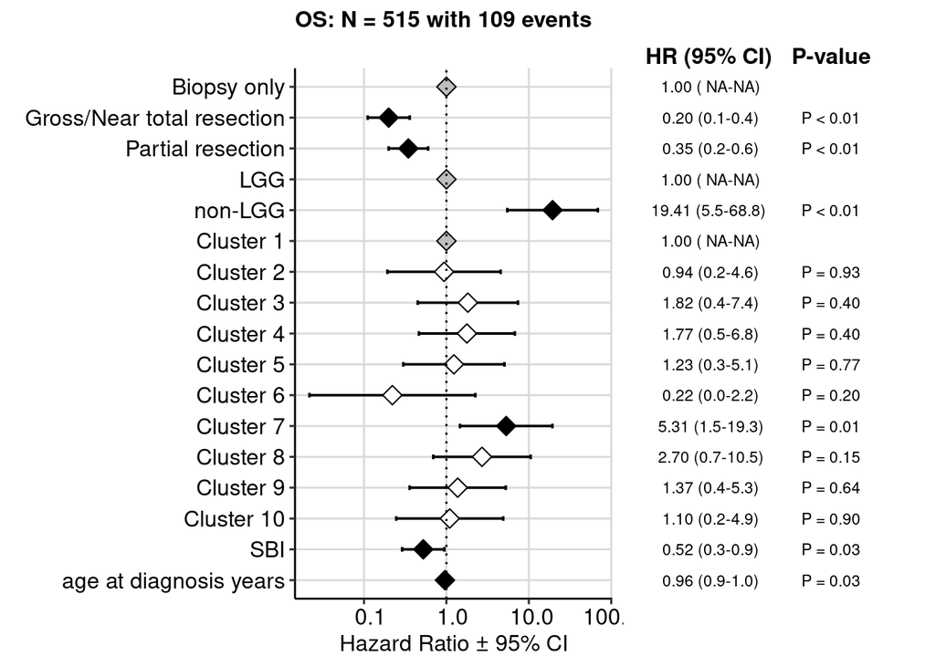

```r
add_model_os <- fit_save_model(metadata[!metadata$extent_of_tumor_resection %in% c("Not Reported", "Unavailable"),],
                              terms = "extent_of_tumor_resection+lgg_group+cluster+age_at_diagnosis_years+SBI",
                               file.path(results_dir, "cox_OS_additive_terms_resection_lgg_group_cluster_SBI.RDS"),
                               "multivariate",
                               years_col = "OS_years",
                               status_col = "OS_status")

forest_os <- plotForest(readRDS(file.path(results_dir, "cox_OS_additive_terms_resection_lgg_group_cluster_SBI.RDS")))
```

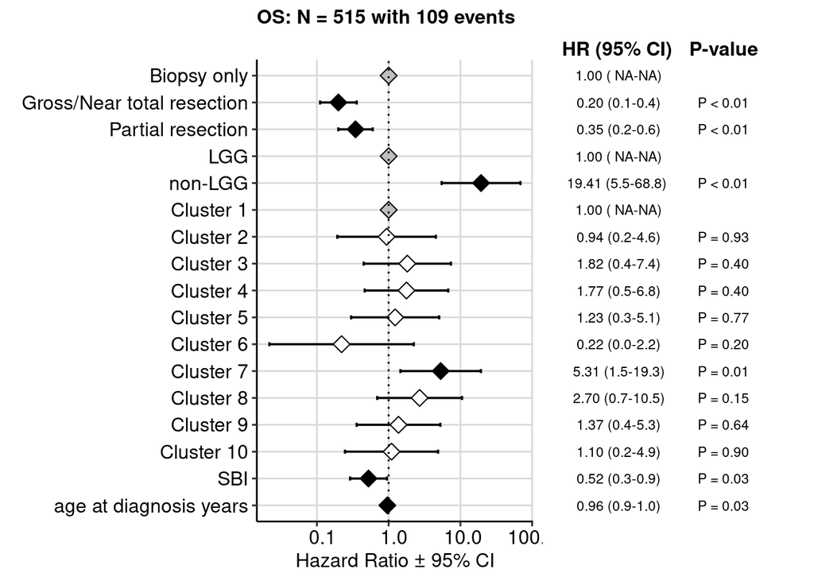

```r
forest_os
```

```
`height` was translated to `width`.
```

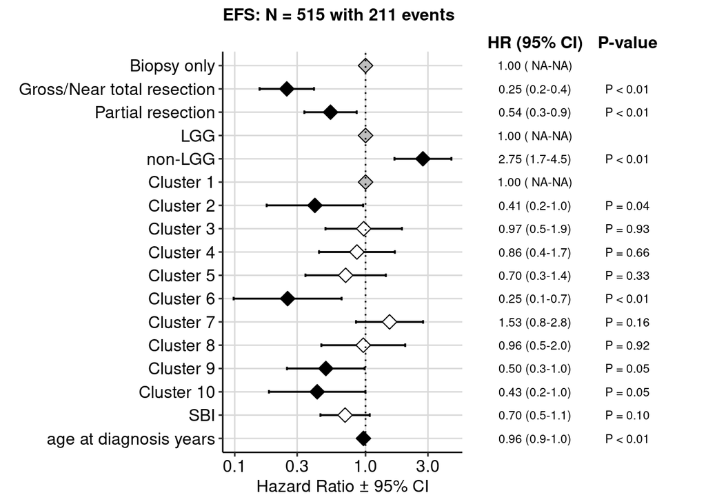

```r
ggsave(file.path(plot_dir, "forest_add_OS_resection_lgg_group_cluster_assignment_SBI.pdf"),
       forest_os,
       width = 10, height = 6, units = "in",
       device = "pdf")

add_model_efs <- fit_save_model(metadata[!metadata$extent_of_tumor_resection %in% c("Not Reported", "Unavailable"),],
                              terms = "extent_of_tumor_resection+lgg_group+cluster+age_at_diagnosis_years+SBI",
                               file.path(results_dir, "cox_EFS_additive_terms_resection_lgg_group_cluster_SBI.RDS"),
                               "multivariate",
                               years_col = "EFS_years",
                               status_col = "EFS_status")

forest_efs <- plotForest(readRDS(file.path(results_dir, "cox_EFS_additive_terms_resection_lgg_group_cluster_SBI.RDS")))
```

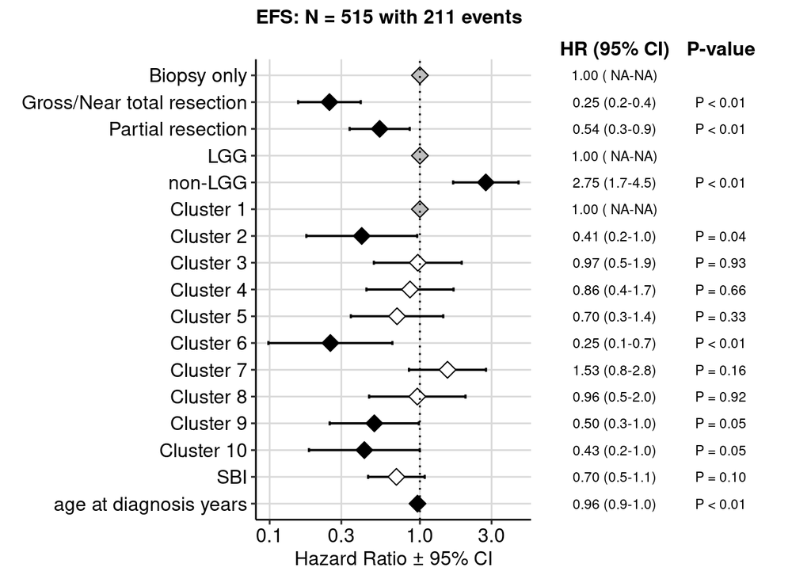

```r
forest_efs
```

```r
ggsave(file.path(plot_dir, "forest_add_EFS_resection_lgg_group_cluster_assignment_SBI.pdf"),
       forest_efs,
       width = 10, height = 6, units = "in",
       device = "pdf")
```

repeat analysis, replacing SBI with KEGG spliceosome gsva score

```
`height` was translated to `width`.
```

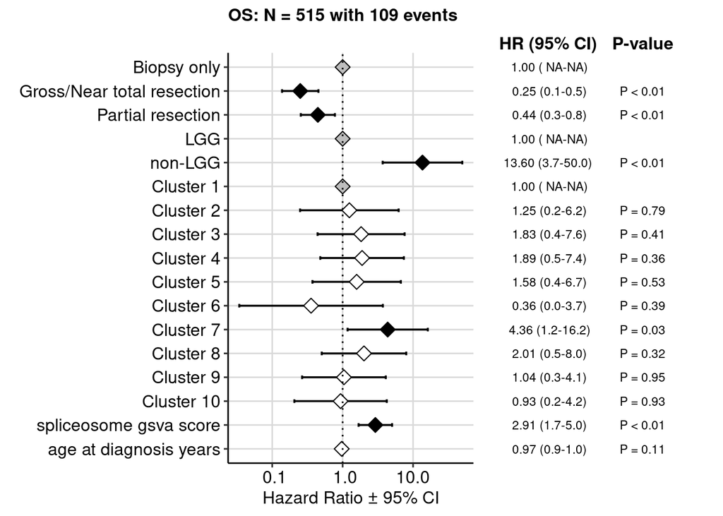

```r
add_model_os <- fit_save_model(metadata[!metadata$extent_of_tumor_resection %in% c("Not Reported", "Unavailable"),],
                              terms = "extent_of_tumor_resection+lgg_group+cluster+age_at_diagnosis_years+spliceosome_gsva_score",
                               file.path(results_dir, "cox_OS_additive_terms_resection_lgg_group_cluster_spliceosome_score.RDS"),
                               "multivariate",
                               years_col = "OS_years",
                               status_col = "OS_status")

forest_os <- plotForest(readRDS(file.path(results_dir, "cox_OS_additive_terms_resection_lgg_group_cluster_spliceosome_score.RDS")))
```

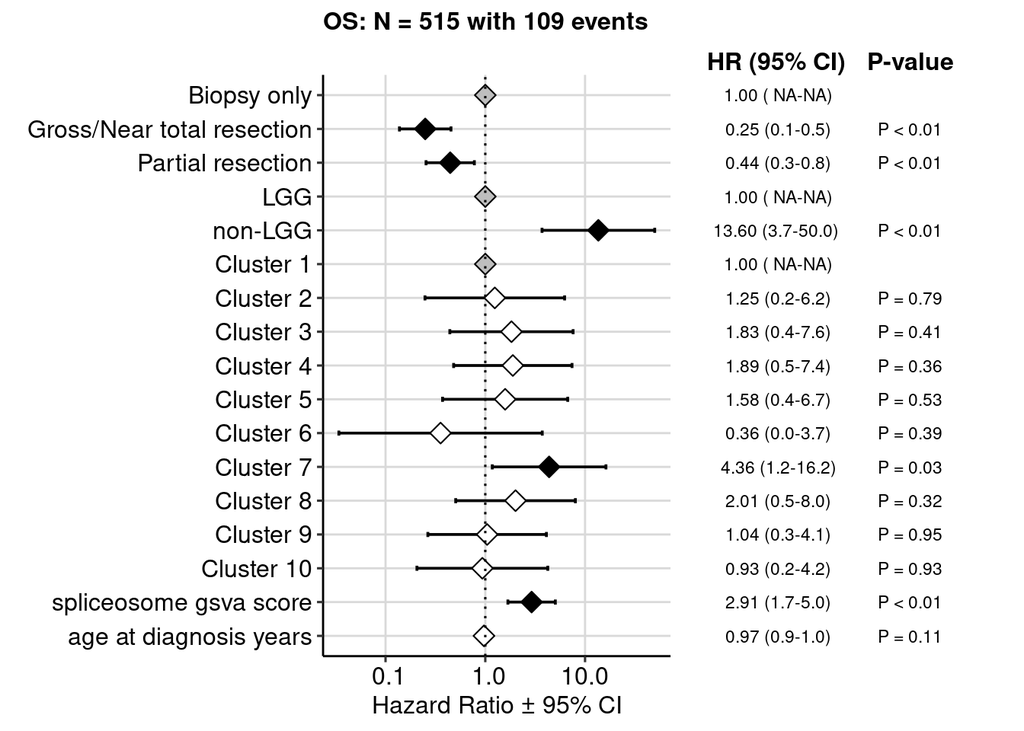

```r
forest_os
```

```r
ggsave(file.path(plot_dir, "forest_add_OS_resection_lgg_group_cluster_assignment_spliceosome_score.pdf"),
       forest_os,
       width = 10, height = 6, units = "in",
       device = "pdf")
```

```
`height` was translated to `width`.
```

```
`height` was translated to `width`.
```

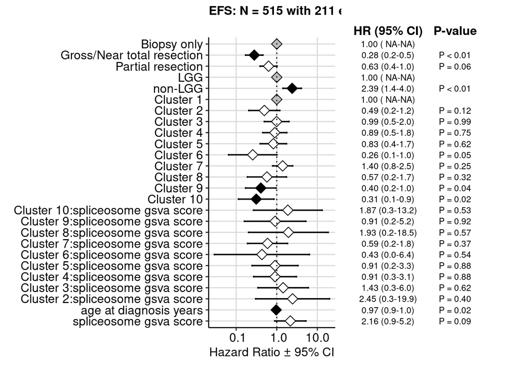

```
`height` was translated to `width`.
```

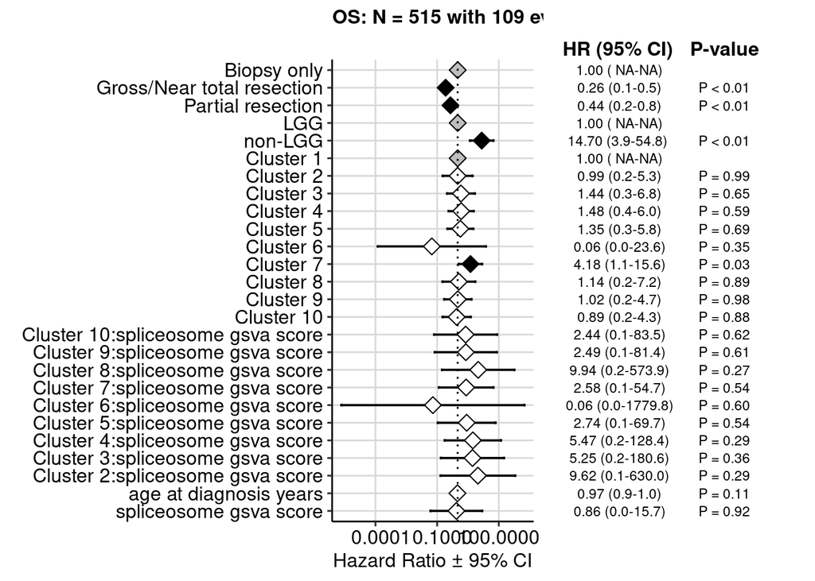

```
`height` was translated to `width`.
```

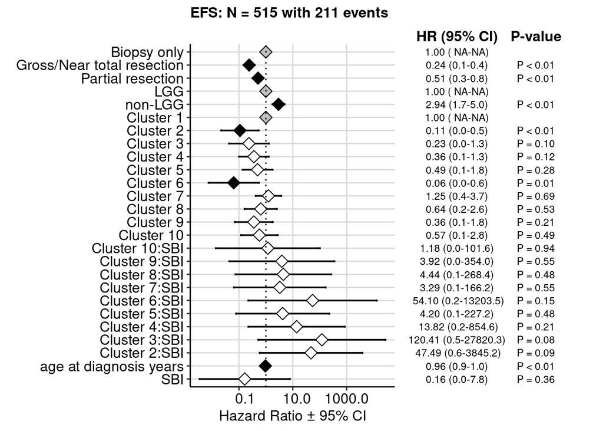

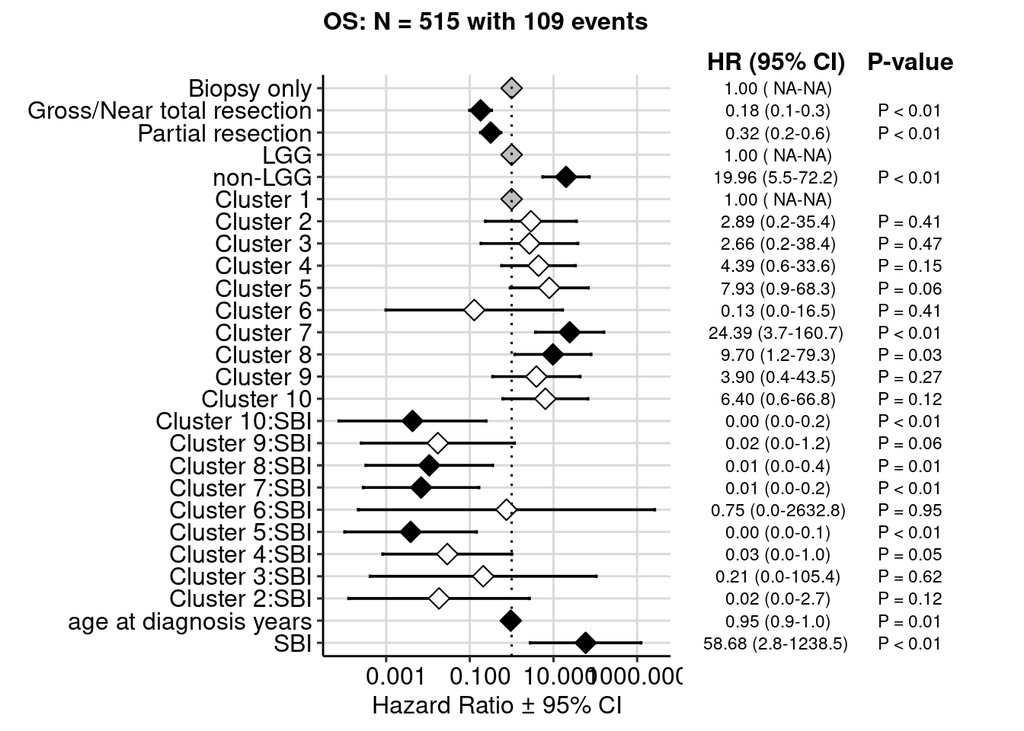

```r
models <- c("spliceosome_gsva_score", "SBI")

for (each in models) {
  int_model_efs <- fit_save_model(metadata[!metadata$extent_of_tumor_resection %in% c("Not Reported", "Unavailable"),],
                                terms = paste0("extent_of_tumor_resection+lgg_group+cluster*", each, "+age_at_diagnosis_years"),
                                 file.path(results_dir, paste0("cox_EFS_interaction_terms_resection_lgg_group_cluster_", each, ".RDS")),
                                 "multivariate",
                                 years_col = "EFS_years",
                                 status_col = "EFS_status")

  int_forest_efs <- plotForest(readRDS(file.path(results_dir, paste0("cox_EFS_interaction_terms_resection_lgg_group_cluster_", each, ".RDS"))))

  int_forest_efs

  ggsave(file.path(plot_dir, paste0("forest_int_EFS_resection_lgg_group_cluster_assignment_", each, ".pdf")),
         int_forest_efs,
         width = 10, height = 6, units = "in",
         device = "pdf")

  int_model_os <- fit_save_model(metadata[!metadata$extent_of_tumor_resection %in% c("Not Reported", "Unavailable"),],
                                terms = paste0("extent_of_tumor_resection+lgg_group+cluster*", each, "+age_at_diagnosis_years"),
                                 file.path(results_dir, paste0("cox_OS_interaction_terms_resection_lgg_group_cluster_", each, ".RDS")),
                                 "multivariate",
                                 years_col = "OS_years",
                                 status_col = "OS_status")

  int_forest_os <- plotForest(readRDS(file.path(results_dir, paste0("cox_OS_interaction_terms_resection_lgg_group_cluster_", each, ".RDS"))))

  int_forest_os

  ggsave(file.path(plot_dir, paste0("forest_int_OS_resection_lgg_group_cluster_assignment_", each, ".pdf")),
         int_forest_os,
         width = 10, height = 6, units = "in",
         device = "pdf")

}
```

```
`height` was translated to `width`.
```

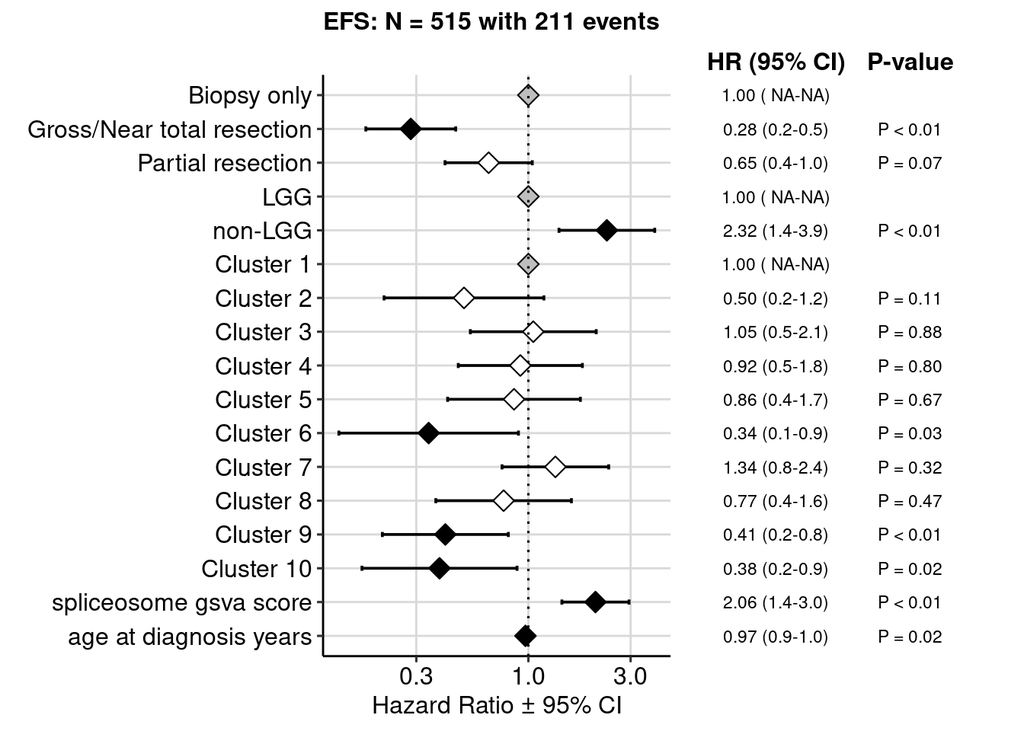

```r
add_model_efs <- fit_save_model(metadata[!metadata$extent_of_tumor_resection %in% c("Not Reported", "Unavailable"),],
                              terms = "extent_of_tumor_resection+lgg_group+cluster+age_at_diagnosis_years+spliceosome_gsva_score",
                               file.path(results_dir, "cox_EFS_additive_terms_resection_lgg_group_cluster_spliceosome_score.RDS"),
                               "multivariate",
                               years_col = "EFS_years",
                               status_col = "EFS_status")

forest_efs <- plotForest(readRDS(file.path(results_dir, "cox_EFS_additive_terms_resection_lgg_group_cluster_spliceosome_score.RDS")))
```

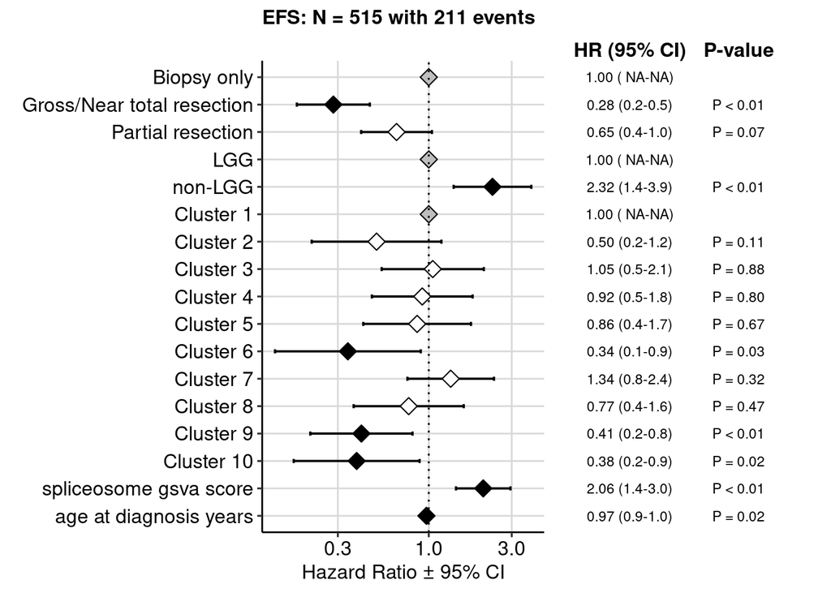

```r
forest_efs
```

```r
ggsave(file.path(plot_dir, "forest_add_EFS_resection_lgg_group_cluster_assignment_spliceosome_score.pdf"),
       forest_efs,
       width = 10, height = 6, units = "in",
       device = "pdf")
```

Subset `metadata` for LGG, and only include clusters with >= 10 samples

```r
lgg <- metadata %>%
  dplyr::filter(plot_group == "Low-grade glioma") %>%
  dplyr::mutate(cluster = factor(cluster)) %>%
  dplyr::mutate(mol_sub_group = fct_relevel(mol_sub_group, "Wildtype", after = 0))

retain_clusters_lgg <- lgg %>%
  dplyr::count(cluster) %>%
  filter(n >= 10) %>%
  pull(cluster)

lgg <- lgg %>%
  filter(cluster %in% retain_clusters_lgg) %>%
    dplyr::mutate(cluster = factor(cluster))
```

Generate coxph models including covariates `extent_of_tumor_resection`, `mol_sub_group`, `cluster`, and `SBI` and plot

```
`height` was translated to `width`.
```

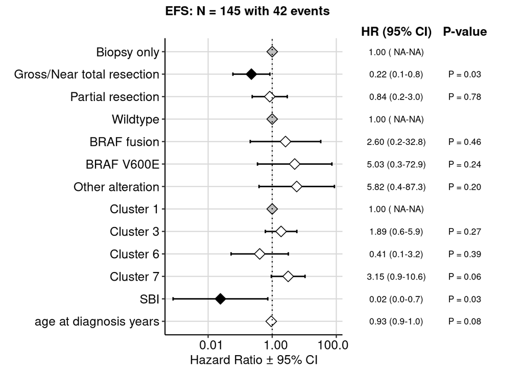

```r
# identify LGG clusters
lgg_clusters <- metadata %>%
  filter(lgg_group == "LGG") %>%
  mutate(cluster = as.integer(gsub("cluster", "", cluster))) %>%
  pull(cluster) %>%
  sort() %>%
  unique()
add_model_lgg_efs <- fit_save_model(lgg[!lgg$cluster %in% lgg_clusters & !lgg$extent_of_tumor_resection %in% c("Not Reported", "Unavailable"),],
                              terms = "extent_of_tumor_resection+mol_sub_group+cluster+age_at_diagnosis_years+SBI",
                               file.path(results_dir, "cox_lgg_EFS_additive_terms_resection_subtype_cluster_SBI.RDS"),
                               "multivariate",
                               years_col = "EFS_years",
                               status_col = "EFS_status")
forest_lgg_efs <- plotForest(readRDS(file.path(results_dir, "cox_lgg_EFS_additive_terms_resection_subtype_cluster_SBI.RDS")))
```

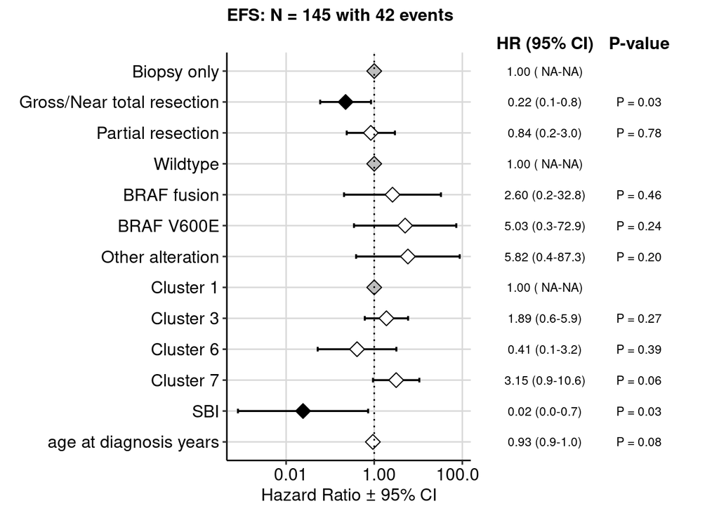

```r
forest_lgg_efs
```

```r
ggsave(file.path(plot_dir, "forest_add_EFS_LGG_resection_subtype_cluster_assignment_SBI.pdf"),
       forest_lgg_efs,
       width = 10, height = 6, units = "in",
       device = "pdf")
```

repeat analysis replacing `SBI` with `spliceosome_gsva_score`

```
`height` was translated to `width`.
```

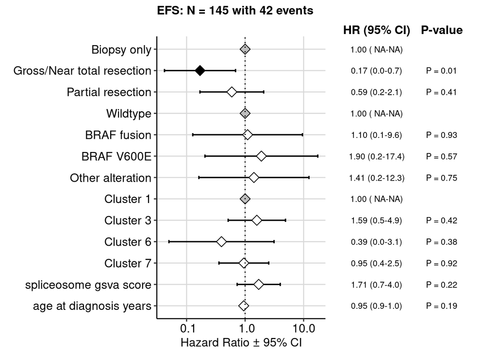

```r
add_model_lgg_efs <- fit_save_model(lgg[!lgg$cluster %in% lgg_clusters & !lgg$extent_of_tumor_resection %in% c("Not Reported", "Unavailable"),],
                              terms = "extent_of_tumor_resection+mol_sub_group+cluster+age_at_diagnosis_years+spliceosome_gsva_score",
                               file.path(results_dir, "cox_lgg_EFS_additive_terms_resection_subtype_cluster_spliceosome_score.RDS"),
                               "multivariate",
                               years_col = "EFS_years",
                               status_col = "EFS_status")
forest_lgg_efs <- plotForest(readRDS(file.path(results_dir, "cox_lgg_EFS_additive_terms_resection_subtype_cluster_spliceosome_score.RDS")))
```

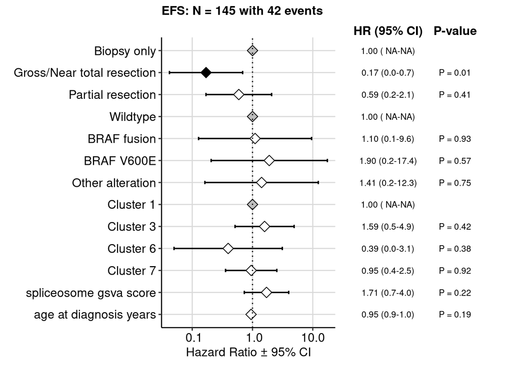

```r
forest_lgg_efs
```

```r
ggsave(file.path(plot_dir, "forest_add_EFS_LGG_resection_subtype_cluster_assignment_spliceosome_score.pdf"),
       forest_lgg_efs,
       width = 10, height = 6, units = "in",
       device = "pdf")
```

Subset `metadata` for HGG and retain cluster with n >= 10

```r
hgg <- metadata %>%
  dplyr::filter(plot_group %in% c("Other high-grade glioma", "Diffuse midline glioma")) %>%
  dplyr::mutate(cluster = factor(cluster)) %>%
  dplyr::mutate(mol_sub_group = fct_relevel(mol_sub_group, "HGG, H3 wildtype", after = 0)) %>%
  dplyr::filter(!is.na(OS_days) | !is.na(EFS_days))

retain_clusters_hgg <- hgg %>%
  dplyr::count(cluster) %>%
  filter(n >= 10) %>%
  pull(cluster)

hgg <- hgg %>%
  filter(cluster %in% retain_clusters_hgg) %>%
  dplyr::mutate(cluster = factor(cluster)) %>%
    dplyr::mutate(SI_group = case_when(
      SBI > summary(SBI)["3rd Qu."] ~ "High SBI",
      SBI < summary(SBI)["1st Qu."] ~ "Low SBI",
      TRUE ~ NA_character_
    )) %>%
  dplyr::mutate(spliceosome_group = case_when(
      spliceosome_gsva_score > summary(spliceosome_gsva_score)["3rd Qu."] ~ "Splice GSVA 4th Q",
      spliceosome_gsva_score > summary(spliceosome_gsva_score)["Median"] ~ "Splice GSVA 3rd Q",
      spliceosome_gsva_score > summary(spliceosome_gsva_score)["1st Qu."] ~ "Splice GSVA 2nd Q",
      TRUE ~ "Splice GSVA 1st Q"
    )) %>%
  dplyr::mutate(SI_group = fct_relevel(SI_group,
                                                 c("High SBI", "Low SBI"))) %>%
  dplyr::mutate(spliceosome_group = fct_relevel(spliceosome_group,
                                                 c("Splice GSVA 1st Q",
                                                   "Splice GSVA 2nd Q",
                                                   "Splice GSVA 3rd Q",
                                                   "Splice GSVA 4th Q")))
```

Generate HGG KM models with `spliceosome_group` as covariate

```r
# Generate kaplan meier survival models for OS and EFS, and save outputs
hgg_kap_os <- survival_analysis(
  metadata  = hgg %>% dplyr::filter(!is.na(spliceosome_group)),
  ind_var = "spliceosome_group",
  test = "kap.meier",
  metadata_sample_col = "Kids_First_Biospecimen_ID",
  days_col = "OS_days",
  status_col = "OS_status"
)
```

```
Testing model: survival::Surv(OS_days, OS_status) ~ spliceosome_group with kap.meier
```

```r
readr::write_rds(hgg_kap_os,
                 file.path(results_dir, "logrank_hgg_OS_splice_group.RDS"))

hgg_kap_efs <- survival_analysis(
  metadata  = hgg %>% dplyr::filter(!is.na(spliceosome_group)),
  ind_var = "spliceosome_group",
  test = "kap.meier",
  metadata_sample_col = "Kids_First_Biospecimen_ID",
  days_col = "EFS_days",
  status_col = "EFS_status"
)
```

```
Testing model: survival::Surv(EFS_days, EFS_status) ~ spliceosome_group with kap.meier
```

```r
readr::write_rds(hgg_kap_efs,
                 file.path(results_dir, "logrank_hgg_EFS_splice_group.RDS"))
```

Generate KM plots

```r
km_hgg_os_plot <- plotKM(model = hgg_kap_os,
                    variable = "spliceosome_group",
                    combined = F,
                    title = "HGG, overall survival",
                    p_pos = "topright")
```

```
Ignoring unknown labels:
• fill : ""
```

```r
ggsave(file.path(plot_dir, "km_hgg_OS_spliceosome_score.pdf"),
       km_hgg_os_plot,
       width = 9, height = 5, units = "in",
       device = "pdf")
```

```
Ignoring unknown labels:
• fill : ""
```

```
Ignoring unknown labels:
• colour : ""
```

```r
km_hgg_efs_plot <- plotKM(model = hgg_kap_efs,
                    variable = "spliceosome_group",
                    combined = F,
                    title = "HGG, event-free survival",
                    p_pos = "topright")
```

```
Ignoring unknown labels:
• fill : ""
```

```r
ggsave(file.path(plot_dir, "km_hgg_EFS_spliceosome_score.pdf"),
       km_hgg_efs_plot,
       width = 9, height = 5, units = "in",
       device = "pdf")
```

```
Ignoring unknown labels:
• fill : ""
```

```
Ignoring unknown labels:
• colour : ""
```

```
`height` was translated to `width`.
```

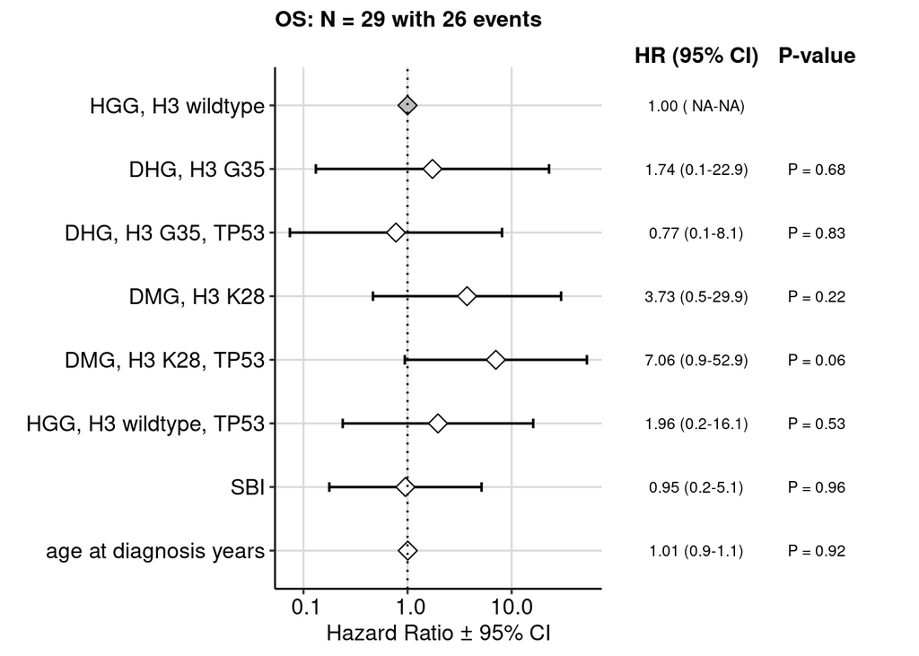

```r
add_model_hgg_os <- fit_save_model(hgg,
                              terms = "mol_sub_group+age_at_diagnosis_years+SBI",
                               file.path(results_dir, "cox_hgg_OS_additive_terms_subtype_cluster_SBI.RDS"),
                               "multivariate",
                               years_col = "OS_years",
                               status_col = "OS_status")
forest_hgg_os <- plotForest(readRDS(file.path(results_dir, "cox_hgg_OS_additive_terms_subtype_cluster_SBI.RDS")))
```

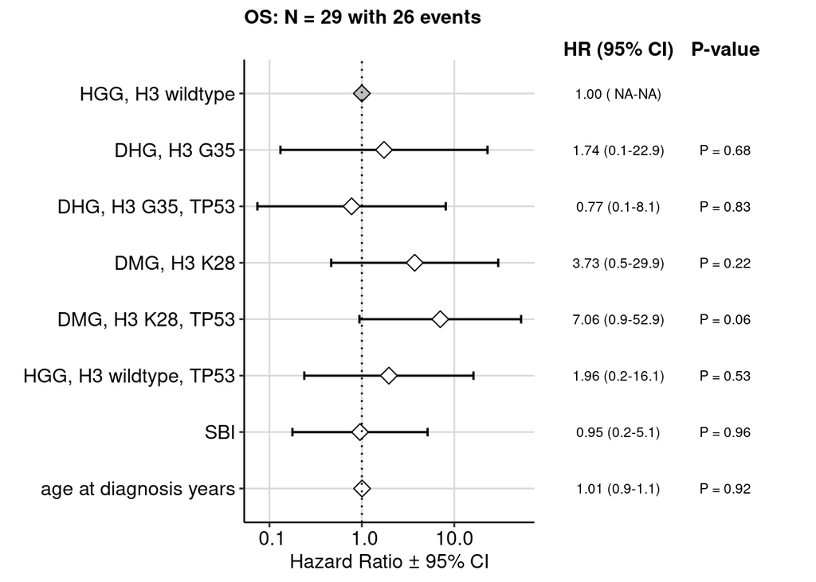

```r
forest_hgg_os
```

```
`height` was translated to `width`.
```

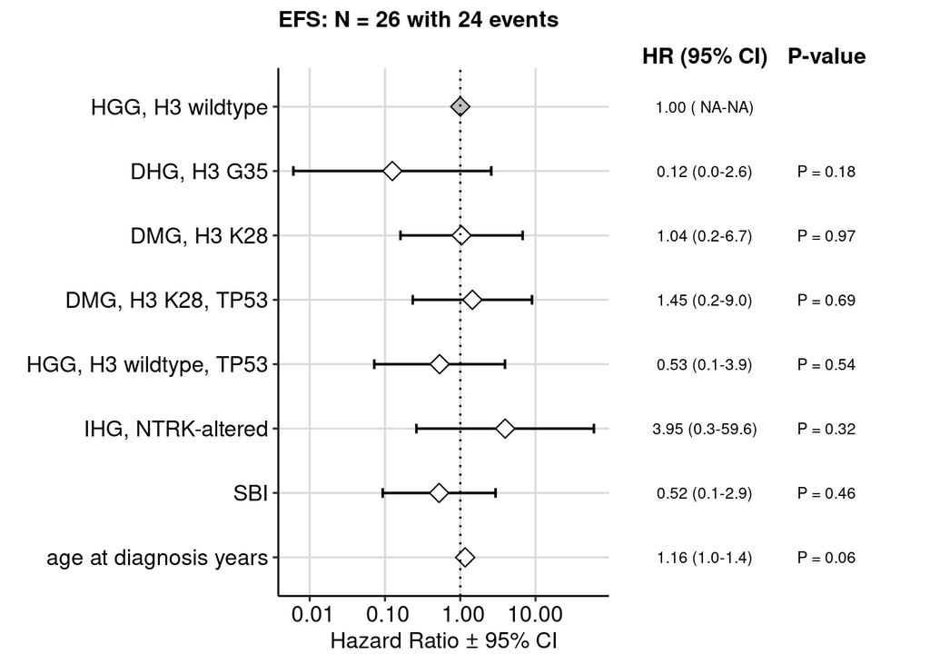

```r
ggsave(file.path(plot_dir, "forest_add_OS_HGG_subtype_cluster_assignment_SBI.pdf"),
       forest_hgg_os,
       width = 9, height = 5, units = "in",
       device = "pdf")

add_model_hgg_efs <- fit_save_model(hgg,
                              terms = "mol_sub_group+age_at_diagnosis_years+SBI",
                               file.path(results_dir, "cox_hgg_EFS_additive_terms_subtype_cluster_SBI.RDS"),
                               "multivariate",
                               years_col = "EFS_years",
                               status_col = "EFS_status")

forest_hgg_efs <- plotForest(readRDS(file.path(results_dir, "cox_hgg_EFS_additive_terms_subtype_cluster_SBI.RDS")))
```

```r
ggsave(file.path(plot_dir, "forest_add_EFS_HGG_subtype_cluster_assignment_SBI.pdf"),
       forest_hgg_efs,
       width = 9, height = 5, units = "in",
       device = "pdf")
```

Repeat analysis replacing `SBI` with `spliceosome_gsva_score`

```
`height` was translated to `width`.
```

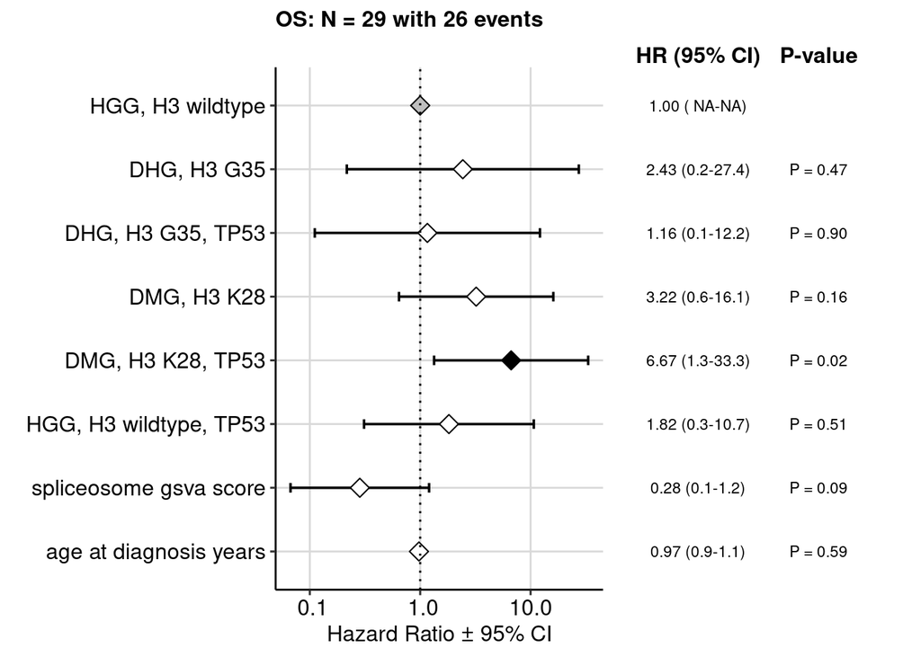

```r
add_model_hgg_os <- fit_save_model(hgg,
                              terms = "mol_sub_group+age_at_diagnosis_years+spliceosome_gsva_score",
                               file.path(results_dir, "cox_hgg_OS_additive_terms_subtype_cluster_spliceosome_score.RDS"),
                               "multivariate",
                               years_col = "OS_years",
                               status_col = "OS_status")
forest_hgg_os <- plotForest(readRDS(file.path(results_dir, "cox_hgg_OS_additive_terms_subtype_cluster_spliceosome_score.RDS")))
```

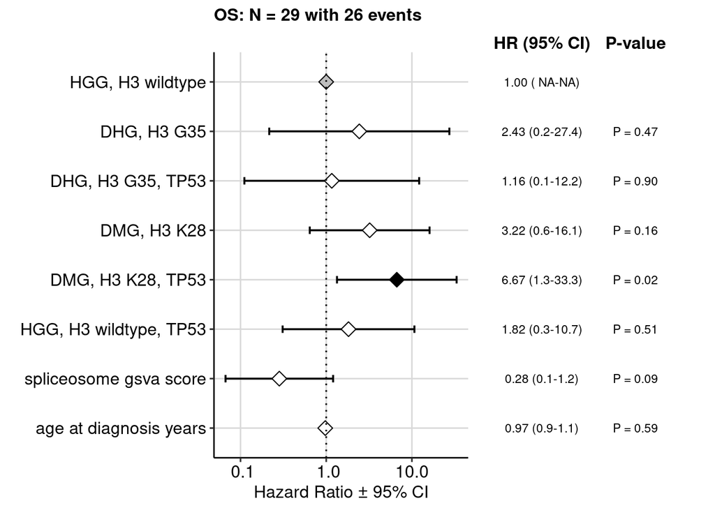

```r
forest_hgg_os
```

```
`height` was translated to `width`.
```

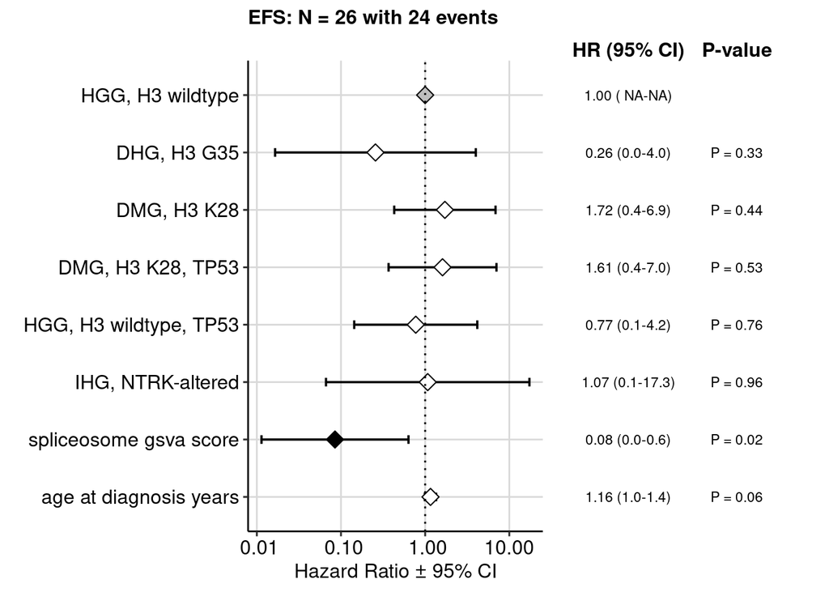

```r
ggsave(file.path(plot_dir, "forest_add_OS_HGG_subtype_cluster_assignment_spliceosome_score.pdf"),
       forest_hgg_os,
       width = 9, height = 5, units = "in",
       device = "pdf")

add_model_hgg_efs <- fit_save_model(hgg,
                              terms = "mol_sub_group+age_at_diagnosis_years+spliceosome_gsva_score",
                               file.path(results_dir, "cox_hgg_EFS_additive_terms_subtype_cluster_spliceosome_score.RDS"),
                               "multivariate",
                               years_col = "EFS_years",
                               status_col = "EFS_status")

forest_hgg_efs <- plotForest(readRDS(file.path(results_dir, "cox_hgg_EFS_additive_terms_subtype_cluster_spliceosome_score.RDS")))
```

```r
ggsave(file.path(plot_dir, "forest_add_EFS_HGG_subtype_cluster_assignment_spliceosome_score.pdf"),
       forest_hgg_efs,
       width = 9, height = 5, units = "in",
       device = "pdf")
```

Filter for cluster 7

```r
cluster7_df <- metadata %>%
  dplyr::filter(cluster == "Cluster 7",
                !is.na(EFS_days)) %>%
  dplyr::mutate(SI_group = case_when(
      SBI > summary(SBI)["3rd Qu."] ~ "High SBI",
      SBI < summary(SBI)["1st Qu."] ~ "Low SBI",
      TRUE ~ NA_character_
    )) %>%
  dplyr::mutate(spliceosome_group = case_when(
      spliceosome_gsva_score > summary(spliceosome_gsva_score)["3rd Qu."] ~ "Splice GSVA 4th Q",
      spliceosome_gsva_score > summary(spliceosome_gsva_score)["Median"] ~ "Splice GSVA 3rd Q",
      spliceosome_gsva_score > summary(spliceosome_gsva_score)["1st Qu."] ~ "Splice GSVA 2nd Q",
      TRUE ~ "Splice GSVA 1st Q"
    )) %>%
  dplyr::mutate(SI_group = fct_relevel(SI_group,
                                                 c("High SBI", "Low SBI"))) %>%
  dplyr::mutate(spliceosome_group = fct_relevel(spliceosome_group,
                                                 c("Splice GSVA 1st Q",
                                                   "Splice GSVA 2nd Q",
                                                   "Splice GSVA 3rd Q",
                                                   "Splice GSVA 4th Q")))
```

Generate KM models with `SI_group` as covariate

```r
# Generate kaplan meier survival models for OS and EFS, and save outputs
c7_si_kap_os <- survival_analysis(
  metadata  = cluster7_df %>% dplyr::filter(!is.na(SI_group)),
  ind_var = "SI_group",
  test = "kap.meier",
  metadata_sample_col = "Kids_First_Biospecimen_ID",
  days_col = "OS_days",
  status_col = "OS_status"
)
```

```
Testing model: survival::Surv(OS_days, OS_status) ~ SI_group with kap.meier
```

```r
readr::write_rds(c7_si_kap_os,
                 file.path(results_dir, "logrank_cluster7_OS_SBI.RDS"))

c7_si_kap_efs <- survival_analysis(
  metadata  = cluster7_df %>% dplyr::filter(!is.na(SI_group)),
  ind_var = "SI_group",
  test = "kap.meier",
  metadata_sample_col = "Kids_First_Biospecimen_ID",
  days_col = "EFS_days",
  status_col = "EFS_status"
)
```

```
Testing model: survival::Surv(EFS_days, EFS_status) ~ SI_group with kap.meier
```

```r
readr::write_rds(c7_si_kap_efs,
                 file.path(results_dir, "logrank_cluster7_EFS_SBI.RDS"))
```

Generate Cluster 7 KM SI_group plots

```r
km_c7_si_os_plot <- plotKM(model = c7_si_kap_os,
                    variable = "SI_group",
                    combined = F,
                    title = "Cluster 7, overall survival",
                    p_pos = "topright")
```

```
Ignoring unknown labels:
• fill : ""
```

```r
ggsave(file.path(plot_dir, "km_cluster7_OS_sbi_group.pdf"),
       km_c7_si_os_plot,
       width = 8, height = 5, units = "in",
       device = "pdf")
```

```
Ignoring unknown labels:
• fill : ""
```

```
Ignoring unknown labels:
• colour : ""
```

```r
km_c7_si_efs_plot <- plotKM(model = c7_si_kap_efs,
                    variable = "SI_group",
                    combined = F,
                    title = "Cluster 7, event-free survival",
                    p_pos = "topright")
```

```
Ignoring unknown labels:
• fill : ""
```

```r
ggsave(file.path(plot_dir, "km_cluster7_EFS_sbi_group.pdf"),
       km_c7_si_efs_plot,
       width = 8, height = 5, units = "in",
       device = "pdf")
```

```
Ignoring unknown labels:
• fill : ""
```

```
Ignoring unknown labels:
• colour : ""
```

Generate KM models with `spliceosome_group` as covariate

```r
# Generate kaplan meier survival models for OS and EFS, and save outputs
c7_splice_kap_os <- survival_analysis(
  metadata  = cluster7_df %>%
    dplyr::filter(spliceosome_group %in% c("Splice GSVA 4th Q", "Splice GSVA 1st Q")) %>%
    dplyr::mutate(spliceosome_group = factor(spliceosome_group,
                                                  levels = c("Splice GSVA 1st Q", "Splice GSVA 4th Q"))),
  ind_var = "spliceosome_group",
  test = "kap.meier",
  metadata_sample_col = "Kids_First_Biospecimen_ID",
  days_col = "OS_days",
  status_col = "OS_status"
)
```

```
Testing model: survival::Surv(OS_days, OS_status) ~ spliceosome_group with kap.meier
```

```r
readr::write_rds(c7_splice_kap_os,
                 file.path(results_dir, "logrank_cluster7_OS_splice_group.RDS"))

c7_splice_kap_efs <- survival_analysis(
  metadata  = cluster7_df %>%
    dplyr::filter(spliceosome_group %in% c("Splice GSVA 4th Q", "Splice GSVA 1st Q")) %>%
    dplyr::mutate(spliceosome_group = factor(spliceosome_group,
                                                  levels = c("Splice GSVA 1st Q", "Splice GSVA 4th Q"))),
  ind_var = "spliceosome_group",
  test = "kap.meier",
  metadata_sample_col = "Kids_First_Biospecimen_ID",
  days_col = "EFS_days",
  status_col = "EFS_status"
)
```

```
Testing model: survival::Surv(EFS_days, EFS_status) ~ spliceosome_group with kap.meier
```

```r
readr::write_rds(c7_splice_kap_efs,
                 file.path(results_dir, "logrank_cluster7_EFS_splice_group.RDS"))
```

Generate Cluster 7 KM spliceosome_group plots

```r
km_c7_splice_os_plot <- plotKM(model = c7_splice_kap_os,
                    variable = "spliceosome_group",
                    combined = F,
                    title = "Cluster 7, overall survival",
                    p_pos = "topright")
```

```
Ignoring unknown labels:
• fill : ""
```

```r
ggsave(file.path(plot_dir, "km_cluster7_OS_splice_group.pdf"),
       km_c7_splice_os_plot,
       width = 9, height = 5, units = "in",
       device = "pdf")
```

```
Ignoring unknown labels:
• fill : ""
```

```
Ignoring unknown labels:
• colour : ""
```

```r
km_c7_splice_efs_plot <- plotKM(model = c7_splice_kap_efs,
                    variable = "spliceosome_group",
                    combined = F,
                    title = "Cluster 7, event-free survival",
                    p_pos = "topright")
```

```
Ignoring unknown labels:
• fill : ""
```

```r
ggsave(file.path(plot_dir, "km_cluster7_EFS_splice_group.pdf"),
       km_c7_splice_efs_plot,
       width = 9, height = 5, units = "in",
       device = "pdf")
```

```
Ignoring unknown labels:
• fill : ""
```

```
Ignoring unknown labels:
• colour : ""
```

Assess EFS and OS by SBI or spliceosome GSVA score in multivariate models and generate forest plots

```
`height` was translated to `width`.
```

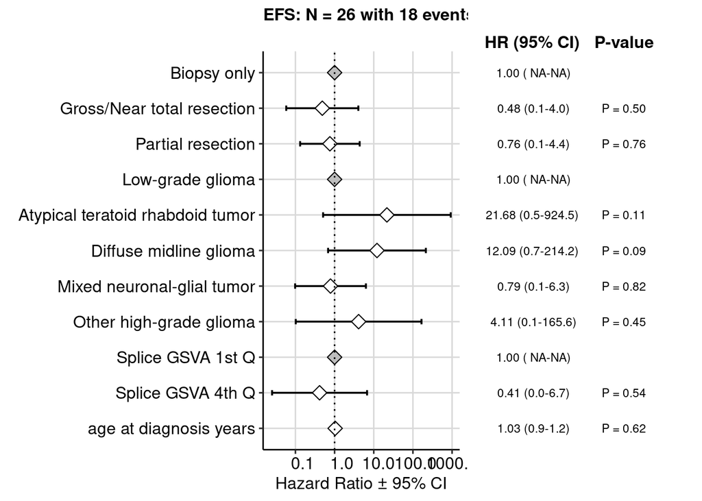

```r
add_model_c7_efs <- fit_save_model(cluster7_df %>%
                                      dplyr::filter(extent_of_tumor_resection != "Unavailable",
                                                    spliceosome_group %in% c("Splice GSVA 4th Q", "Splice GSVA 1st Q")) %>%
                                      dplyr::mutate(plot_group = fct_relevel(plot_group, "Low-grade glioma", after = 0)),
                              terms = "extent_of_tumor_resection+age_at_diagnosis_years+plot_group+spliceosome_group",
                               file.path(results_dir, "cox_hgg_EFS_additive_terms_subtype_cluster_spliceosome_score.RDS"),
                               "multivariate",
                               years_col = "EFS_years",
                               status_col = "EFS_status")
forest_c7_spliceosome_efs <- plotForest(readRDS(file.path(results_dir, "cox_hgg_EFS_additive_terms_subtype_cluster_spliceosome_score.RDS")))
```

```
`height` was translated to `width`.
```

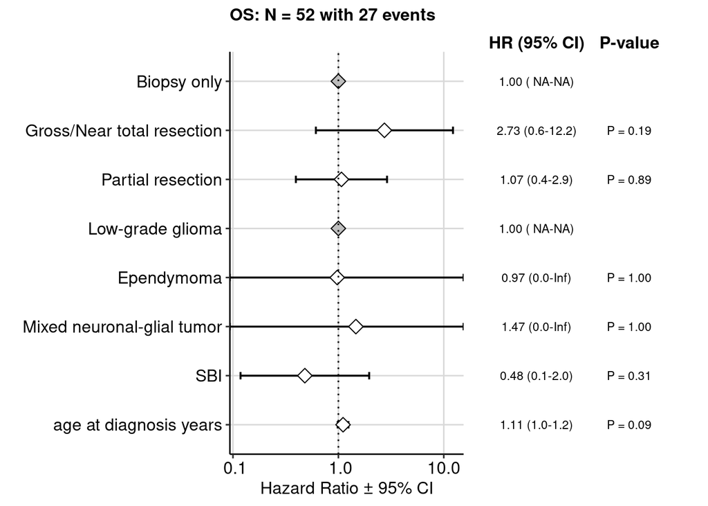

```r
ggsave(file.path(plot_dir, "forest_add_EFS_cluster7_histology_resection_spliceosome_group.pdf"),
       forest_c7_spliceosome_efs,
       width = 9, height = 4, units = "in",
       device = "pdf")

add_model_c7_os <- fit_save_model(cluster7_df %>%
                                    dplyr::filter(!extent_of_tumor_resection %in% c("Not Reported", "Unavailable")) %>%
                                    dplyr::mutate(plot_group = fct_relevel(plot_group, "Low-grade glioma", after = 0)),
                              terms = "extent_of_tumor_resection+age_at_diagnosis_years+plot_group+SBI",
                               file.path(results_dir, "cox_hgg_OS_additive_terms_subtype_cluster_si_group.RDS"),
                               "multivariate",
                               years_col = "OS_years",
                               status_col = "OS_status")
forest_c7_si_os <- plotForest(readRDS(file.path(results_dir, "cox_hgg_OS_additive_terms_subtype_cluster_si_group.RDS")))
```

```r
ggsave(file.path(plot_dir, "forest_add_OS_cluster7_histology_resection_si.pdf"),
       forest_c7_si_os,
       width = 9, height = 4, units = "in",
       device = "pdf")
```